# Project: Data Visualization

## Author: Robert HROMADA (SVK)

### ProsperLoan Data Exploration

### Factors that have an impact on loan approval for an applicant

### Dataset description

Prosper or Prosper Marketplace Inc. is a San Francisco, California [3] based company specializing in loans at low interest rates to the borrowers.

Prosper Loan dataset contains 113,937 loans with 81 variables on each loan, including loan amount, borrower rate (or interest rate), current loan status, borrower income, and many others. Not all of them require to be analyzed.

All data are explained in dictionary provided by Prosper Loan.

Dataset contains a lot of messy and tidy data. But the goal of this project is not to clean all findings.

Our effort will be focused on facts which have an impact on borrowers’ request for loan from Prosper Loan.

Due to fact that Prosper Loan business area is loan providing, we can expect that they need to be sure that every borrower will be able to:

- pay regularly for their loan,
- have appropriate income for appropriate loan high.

## Part I - Gathering Data

Dataset was provided by Udacity.

## Part II - Assessing Data

Dataset contains 81 diffrent variables and 113937 rows with values of these variables in Prosper Loan Data.

In the dataset there are missing values.

A lot of variables seem to be administrative ID's (e.g. ListingKey and ListingNumber), and we can delete them. They are not usefull for us in this project.

There are 17 variables of type object. Those will probably need some attention before further steps.

CreditScoreRangeLower and CreditScoreRangeUpper values can be converted into a single CreditScore value (calculate average of the two variables).

LoanOriginalDate should be in date format.

LoanOriginalQuarter can be split into two columns.

Columns ProsperRating (numeric), ProsperRating (Alpha) and ListingCategory (numeric) have strange name. It should be rename.

Column ListingCategory(numecal) is Float64 type. For easier work with categorical data we can tranfer it into string value.

In our analysis we will focus on facts which have impact on borrowers reguest for loan from Prosper Loan.

Due to fact that Prosper Loan bussiness area is Loan Providing, we can expect that they need to be sure that every borrower will be able to:

- pay regulary for their loan,
- have appropriate income for apropriate loan high.

## Part III - Cleaning Data

Main effort in this project is put on "Communicate Data Findings".

As a result of this, only basic cleaning of the dataset was made.

## Part IV - Data Visualization

In our final slide deck deliverable, we will focus on these points from our analysis:

- How has Prosper Loan business changed over years?
- Who are the Prosper Loan customers?
- What is the preferable lenght for loan?
- Who is the best candidate for Prosper Loan from the POV of the company?
- Which features are highly impactful for approval of loan status?
- What is the main reason for the acquiring the loan?

We can easily say that major insights obtained are:

- EmploymentStatus
- StatedMonthlyIncome
- ProsperScore
- ProsperRatingAplha.

Will explain how these factors affect decition of Prosper Loan to agree with loan for borrowers.

#### How has Prosper Loan business changed over years?

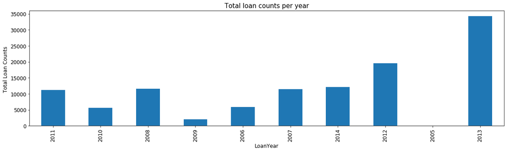

```python
# Total Loan Counts per year

plt.title('Total loan counts per year', fontsize=15)
plt.xlabel("Year", fontsize=12)
plt.ylabel("Total Loan Counts ",fontsize=12);

graph('LoanYear', 'v')
```

We can see two maximums: one in 2007-2008 and the second one in 2013. After these years the total amount of loaned money fell down. This situation with loans could have many different reasons. One, highly probable, is the Global financial crisis in 2009. Almost similar situation repeated in 2014 with the European debt crisis which influenced US capital market as well.

#### Who are the Prosper Loan customers?

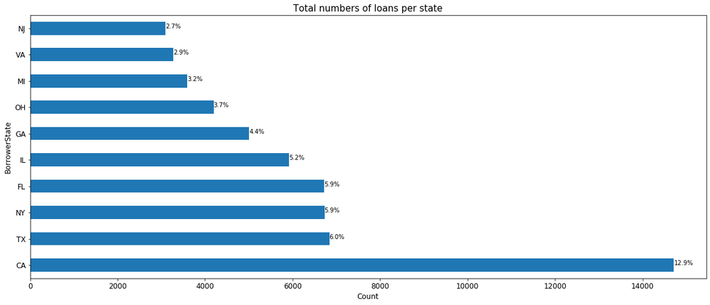

```python
# Loans counts in states

plt.title('Total numbers of loans per state', fontsize=15)
plt.xlabel('Count', fontsize=12)

graph('BorrowerState', 'h')
```

Prosper or Prosper Marketplace Inc. is a San Francisco, California [3] based company specializing in loans at low interest rates to the borrowers.

California has the largest number of borrowers. California is at the TOP probably due to fact that Prosper Loan was founded and is located in California. The other popular states include Texas, New York, Florida and Illinois.

#### What is the preferable lenght for loan?

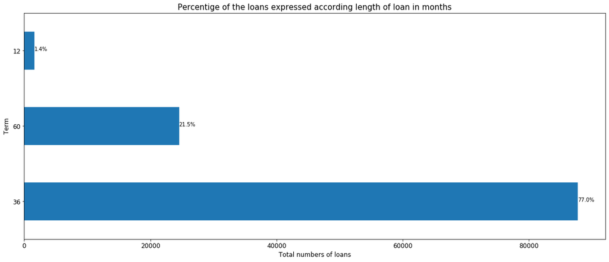

```python
#Loan Lenght
plt.title('Percentige of the loans expressed according length of loan in months', fontsize=15)
plt.xlabel("Total numbers of loans",fontsize=12)

graph('Term', 'h')
```

More that 75% of Prosper Loan customers prefer taking a loan for 36 month period.

#### Who is the best candidate for Prosper Loan from the POV of the company?

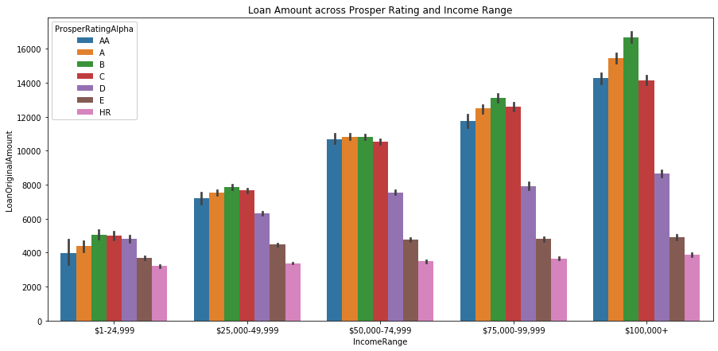

```python
#Loan Amount across Prosper Rating and Income Range

working_df_sub1 = working_df[working_df['StatedMonthlyIncome'] <= 25000]

working_df_sub1['IncomeRange'] = working_df_sub1['IncomeRange'].cat.remove_categories(['Not employed','$0', 'Not displayed'])

plt.figure(figsize = [15, 7])

ax = sns.barplot(data = working_df_sub1, x = 'IncomeRange', y = 'LoanOriginalAmount', hue = 'ProsperRatingAlpha')
ax.legend(loc = 0, ncol = 1, framealpha = 1, title = 'ProsperRatingAlpha')
plt.title('Loan Amount across Prosper Rating and Income Range');
```

LoanOriginalAmout dependes on IncomeRange. If a borrower has higher IncomeRange for the Prosper Loan it is an indicator that they will be able to fulfil their commitment and they will be able to pay regularly. If we look closer to each IncomeRange we can recognize, that there is something like "safety policy" from Prosper Loan that client with rating "E" or "HR" are not allowed to have a loan higher than 5 000 USD even in case of higher IncomeRange.

#### Which features are highly impactful for approval of loan status?

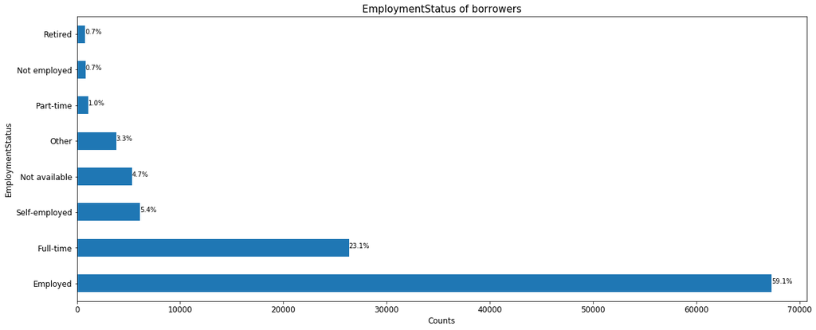

```python
# Employment status
plt.title('EmploymentStatus of borrowers', fontsize=15)
plt.xlabel("Counts",fontsize=12)


graph('EmploymentStatus', 'h')
```

Borrower who is employed is definitely a suitable client for Prosper Loan. More than 70% of Prosper Loan clients are employed. Client who mentioned "Other" or nothing as their employment status probably proved their ability to pay in some other way and they were approved by Prosper Loan. But percentige of these clients is quite low.

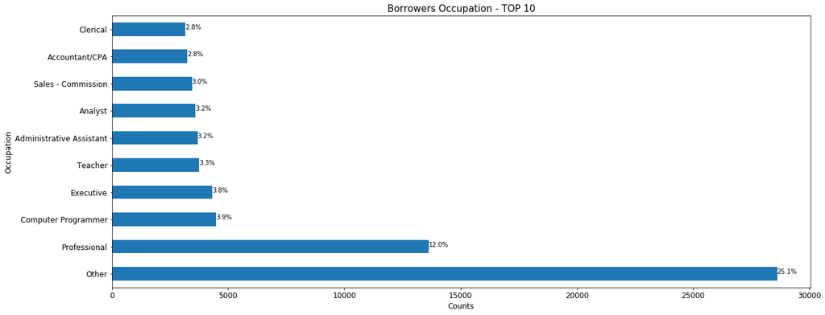

```python
# TOP 10 Borrower Occupation
plt.title('Borrowers Occupation - TOP 10', fontsize=15)
plt.xlabel("Counts",fontsize=12)

graph('Occupation', 'h')
```

The most mentioned occupations in Loan request were ‘Other’ and ‘Professional’. It is really interesting that borrowers did not mentione exatly their occupation. But this is not an issue for Prosper Loan.

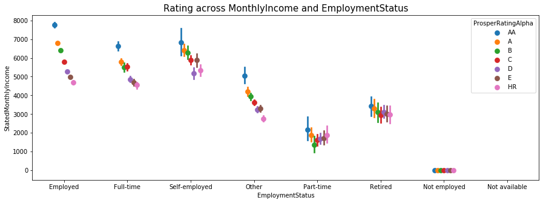

```python
# Rating across Monthly Income and EmploymentStatus

working_df_sub = working_df[working_df['StatedMonthlyIncome'] <= 25000]

plt.figure(figsize = [15, 5])

order = ['Employed', 'Full-time', 'Self-employed', 'Other', 'Part-time', 'Retired', 'Not employed', 'Not available']
ax = sns.pointplot(data = working_df_sub, x = 'EmploymentStatus', y = 'StatedMonthlyIncome', hue = 'ProsperRatingAlpha',
                  dodge = 0.3, linestyles = "", order = order)

plt.title('Rating across MonthlyIncome and EmploymentStatus', fontsize=15);
```

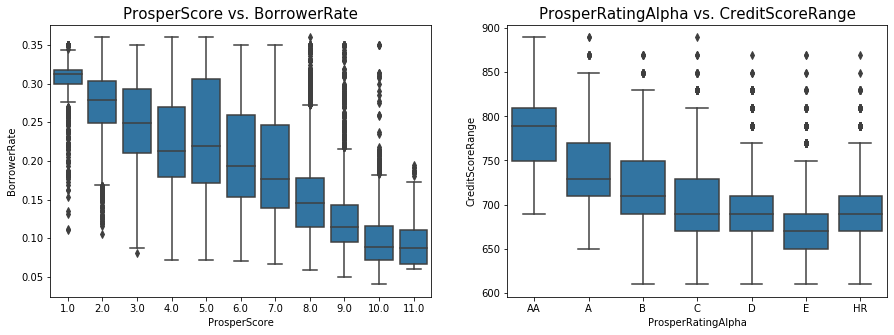

```python
# ProsperScore vs. BorrowerRate and ProsperRatingAlpha vs. CreditScoreRange

plt.figure(figsize = [15, 5 ])
base_color = sns.color_palette()[0]
# left plot BorrowerRate vs. ProsperScore
plt.subplot(1, 2, 1)

sns.boxplot(data = working_df, x = 'ProsperScore', y = 'BorrowerRate', color = base_color);
plt.title('ProsperScore vs. BorrowerRate', fontsize=15);

# Right plotCreditScoreRange vs. ProsperRatingAlpha
plt.subplot(1, 2, 2)
sns.boxplot(data = working_df, x = 'ProsperRatingAlpha', y = 'CreditScoreRange', color = base_color)
plt.title('ProsperRatingAlpha vs. CreditScoreRange', fontsize=15);
```

We can see that borrowers with higher ProsperScore have lower borrower rate. Outliers could be due to other factors such as the amount of loan taken, new monthly income or employment status or some others.

The same pattern is visible with CreditScoreRange vs. ProsperRatingAlpha. For rating AA we can observe higher CreditScoreRandge than for HR rating.

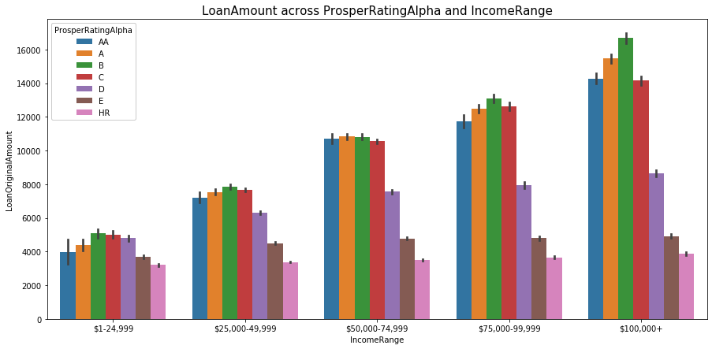

```python
working_df_sub = working_df[working_df['StatedMonthlyIncome'] <= 25000]

working_df_sub1['IncomeRange'] = working_df_sub['IncomeRange'].cat.remove_categories(['Not employed','$0', 'Not displayed'])

plt.figure(figsize = [15, 7])


ax = sns.barplot(data = working_df_sub1, x = 'IncomeRange', y = 'LoanOriginalAmount', hue = 'ProsperRatingAlpha')
ax.legend(loc = 0, ncol = 1, framealpha = 1, title = 'ProsperRatingAlpha')
plt.title('LoanAmount across ProsperRatingAlpha and IncomeRange', fontsize=15);
```

LoanOriginalAmout definitely depends on IncomeRange. If borrower has higher IncomeRange for the Prosper Loan it is an indicator that they will be able to fullfil their commitmet. If we look closer at each IncomeRange we can regognazed that clients with rating "E" or "HR" are not allowed to have a loan higher than 5 000 USD even in case of higher IncomeRange.

Further investigation could concern the question why do people with such a high income e.g. more than 70 000 USD are in a need of taking loan from Prosper Loan.

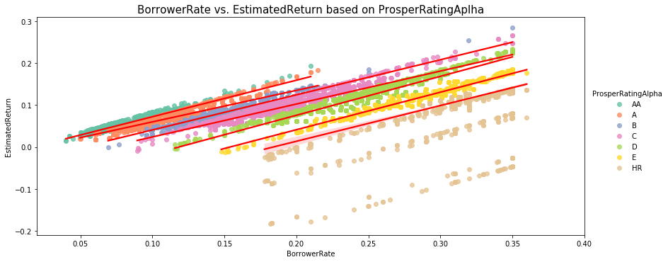

```python
#BorrowerAPR / BorrowerRate vs. EstimatedReturn based on ProsperRatingAplha

g = sns.lmplot(x="BorrowerRate", y="EstimatedReturn", hue="ProsperRatingAlpha", data=working_df, line_kws={'color': 'red'},
               palette="Set2", size=5, aspect = 2.35)

# Use more informative axis labels than are provided by default
g.set_axis_labels("BorrowerRate", "EstimatedReturn");
plt.title('BorrowerRate vs. EstimatedReturn based on ProsperRatingAplha', fontsize=15)

g.set(xlim=(0.02, 0.4))
#g.set(ylim=(0, 2000))

sns.despine(fig=None, ax=None, top=False, right=False, left=False, bottom=False, offset=None, trim=False);
```

From the plot we can see that the ProsperRatingAplha has a direct impact on relation between BorrowerRate and EstimatedReturn.

In case that boorowers have ProsperRatingAlpha "AA" or "A" category they have definitely better BorrowerRate than clients with "E" or "HR" category.

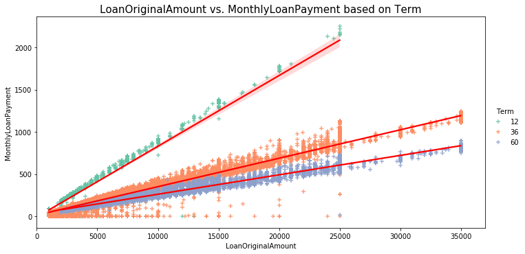

```python
# LoanOriginalAmount vs. MonthlyLoanPayment by Term

g = sns.lmplot(x="LoanOriginalAmount", y="MonthlyLoanPayment", hue="Term", data=working_df, line_kws={'color': 'red'},
              markers=["+", "+", '+'], palette="Set2", size=5, aspect = 2)

# Use more informative axis labels than are provided by default
g.set_axis_labels("LoanOriginalAmount", "MonthlyLoanPayment")
plt.title('LoanOriginalAmount vs. MonthlyLoanPayment based on Term', fontsize=15)

g.set(xlim=(0, 37000))
#g.set(ylim=(0, 2500))

sns.despine(fig=None, ax=None, top=False, right=False, left=False, bottom=False, offset=None, trim=False);
```

Higher MothlyLoanPayment is expectable in case of high LoanOriginalAmount and short Term for paying back the whole Loan.

For ther shortest lenght of loan we can see that Prosper Loan allowes to take max up to 25 000 USD.

Another interestin fact is that borrowers who take the same amount of loan but for longer period (60 month) in final they will pay much more than clients with shorten term for a loan (36 month).

#### What is the main reason for the loan?

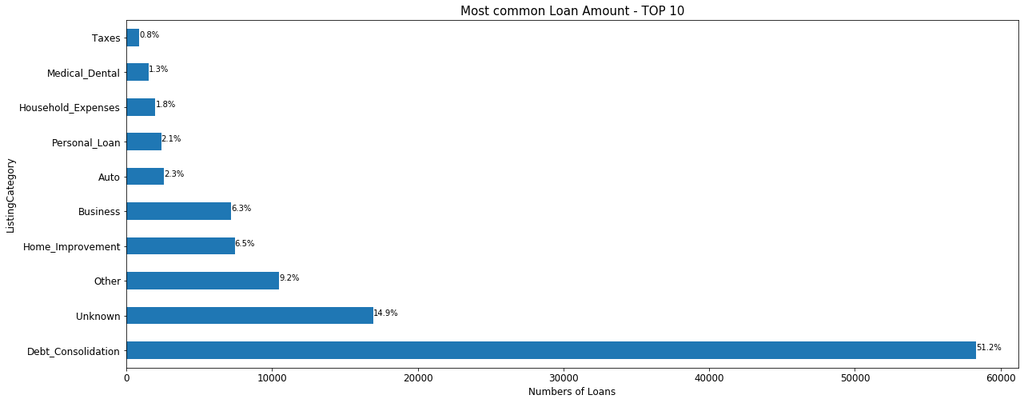

```python
# Most common Loan Amount - TOP 10
plt.title('Most common Loan Amount - TOP 10', fontsize=15)
plt.xlabel("Numbers of Loans",fontsize=12)


graph('ListingCategory', 'h')
```

Main reason for loan is Debt Consolodation which seems to be realy interesting due to fact that borrower take another loan to pay back the previuos ones.

It is really strange that people took loans to reimburse loans/debts and lenders also issued loans to these people. Isn’t is a bad idea to take loans to pay for loans?

The reason in this case can be e.g. better "BorrowerRate" in a new loan.

## Resources

[1] [Global financial crisis in 2009](https://en.wikipedia.org/wiki/Global_financial_crisis_in_2009)

[2] [The effect of the global financial crisis on OECD potential output](https://www.oecd.org/economy/growth/the-effect-of-the-global-financial-crisis-on-oecd-potential-output-oecd-journal-economic-studies-2014.pdf)

[3] [Prosper Funding LLC](https://www.prosper.com/plp/about/contact-us/)